# **Inferência Estatística Aplicada à Avaliação de Efeitos de Tratamentos Médicos**

#### Autor: Luis Rito Filipe

#### Agosto de 2025

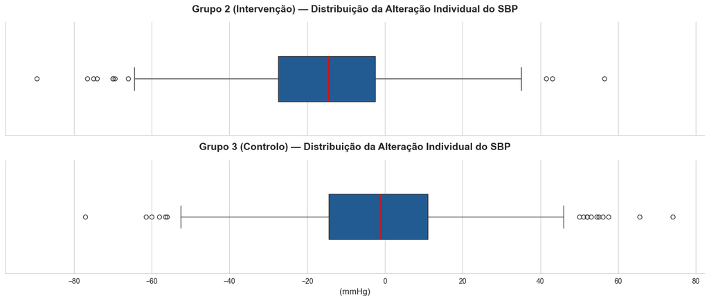

# Sumário

Este estudo investiga se uma intervenção digital multifacetada para a gestão da hipertensão esteve associada a uma alteração significativa da pressão arterial sistólica em comparação com um grupo de controlo, ao longo de um período de 12 meses. A análise utiliza medições da pressão arterial sistólica ao nível de cada doente, realizadas no início e no final do estudo, para calcular a alteração individual de cada participante. As estatísticas descritivas são seguidas por um teste t de Welch para duas amostras e por um intervalo de confiança de 95%, de modo a avaliar a diferença entre a alteração individual média dos grupos de intervenção e de controlo.

O grupo de intervenção apresentou uma redução substancialmente maior da pressão arterial sistólica, com uma diferença observada de aproximadamente −13,75 mmHg em comparação com o grupo de controlo. A análise estatística fornece uma evidência muito forte de uma diferença entre os grupos, com uma estatística t de −14,15 e um valor p de 5,63 × 10⁻⁴³. O intervalo de confiança de 95% correspondente varia entre −15,65 e −11,84 mmHg.

O estudo analisa também os pressupostos subjacentes ao teste estatístico e avalia a potencial influência de observações extremas.

# Sobre o Estudo

Este estudo utiliza o conjunto de dados CHESS_database_revise, que contém dados da avaliação do Comprehensive intelligent Hypertension managEment SyStem (CHESS). Os dados são provenientes do estudo “Effect of a multifaceted digital intervention system to improve hypertension management in primary care: an open-label, cluster randomized controlled trial.” O estudo original avaliou uma intervenção digital multifacetada concebida para melhorar a gestão da hipertensão nos cuidados de saúde primários. O ensaio utilizou uma aleatorização por agrupamentos, tendo os locais participantes sido atribuídos ao grupo de intervenção ou ao grupo de controlo.

O principal objetivo deste projeto não é reproduzir a metodologia estatística completa do ensaio clínico original, mas sim aplicar e demonstrar conceitos fundamentais de inferência estatística, incluindo testes de hipóteses, valores-p, intervalos de confiança e avaliação de diagnóstico.

[Está disponível outra versão desta publicação](https://luisritofilipe.github.io/data_science_learning/Assessing_medical_treatment_effects_with_inferential_statistics_with_code.html) que inclui o código Python utilizado na preparação dos dados, manipulação e cálculo estatístico. A presente versão concentra-se na metodologia, nos resultados e na interpretação, omitindo excertos de código para melhorar a legibilidade e a apresentação visual.

# Sobre o Conjunto de Dados

Este estudo utiliza o conjunto de dados Comprehensive intelligent Hypertension managEment SyStem (CHESS), disponibilizado publicamente pelo Dryad (ver ligação abaixo), que contém registos de uma intervenção digital multifacetada concebida para melhorar a gestão da hipertensão nos cuidados de saúde primários.

Ligação de acesso ao conjunto de dados: https://datadryad.org/dataset/doi:10.5061/dryad.18931zdb7

# Metodologia

- Tratamento e Pré-processamento de Dados
- Questão Estatística
- Questão de Investigação
- As Hipóteses Estatísticas
- Estatística Descritiva
- Inferência Estatística
- Teste de Hipóteses com Teste Estatístico t de Welch
- Intervalo de Confiança
- Pressupostos e Verificações de Diagnóstico
- Interpretação e Limitações
- Conclusões

# Tratamento e Pré-processamento de Dados

O conjunto de dados utilizado neste estudo é o CHESS_database_revise, que contém um grande conjunto de medições da pressão arterial sistólica e diastólica dos doentes. Foi selecionado apenas um subconjunto das variáveis relevantes para a presente análise. Estas variáveis incluem o identificador do grupo de doentes, a pressão arterial sistólica no início da experiência, a pressão arterial sistólica no final da experiência, o identificador do local, o género e o grupo etário. As estatísticas descritivas destas variáveis são apresentadas abaixo.

```
<class 'pandas.core.frame.DataFrame'> RangeIndex: 1666 entries, 0 to 1665 Columns: 6 entries, group to Age_group dtypes: float64(2), int64(3), object(1) memory usage: 78.2+ KB
```

|  | group | RAND_SYSBP | FU_SYSBP_FU4 | SITEID | Gender | Age_group |
| --- | --- | --- | --- | --- | --- | --- |
| count | 1666.000000 | 1666.000000 | 1660.000000 | 1666.000000 | 1666.000000 | 1666 |
| unique | NaN | NaN | NaN | NaN | NaN | 5 |
| top | NaN | NaN | NaN | NaN | NaN | 50-60 |
| freq | NaN | NaN | NaN | NaN | NaN | 694 |
| mean | 2.490996 | 141.946279 | 133.444277 | 6205.684274 | 0.444778 | NaN |
| std | 0.500069 | 17.077309 | 15.949260 | 77.566029 | 0.497090 | NaN |
| min | 2.000000 | 95.500000 | 91.000000 | 6103.000000 | 0.000000 | NaN |
| 25% | 2.000000 | 130.500000 | 122.500000 | 6113.000000 | 0.000000 | NaN |
| 50% | 2.000000 | 141.000000 | 132.000000 | 6208.000000 | 0.000000 | NaN |
| 75% | 3.000000 | 152.000000 | 143.500000 | 6303.000000 | 1.000000 | NaN |
| max | 3.000000 | 224.500000 | 190.000000 | 6313.000000 | 1.000000 | NaN |

Foi identificado um pequeno número de valores em falta entre as variáveis necessárias para a análise. Estes registos foram excluídos da análise estatística.

| Feature | Count |
| --- | --- |
| FU_SYSBP_FU4 | 6 |

# Questão Estatística

## Questão de Investigação

O objetivo deste estudo é determinar se a intervenção CHESS produziu uma redução da pressão arterial sistólica superior à dos cuidados habituais após 12 meses. O resultado principal é a pressão arterial sistólica (SBP), medida no início do estudo e novamente após 12 meses.

Em vez de simplesmente comparar a pressão arterial média dos dois grupos no final do estudo, iremos analisar a alteração da pressão arterial sistólica entre o início do estudo e os 12 meses. Assim, um valor negativo representa uma redução da pressão arterial sistólica.

O efeito do tratamento será então estimado como a diferença entre a alteração individual média no grupo de intervenção e a alteração individual média no grupo de controlo.

As principais questões estatísticas são portanto, **“A diferença na alteração individual média da pressão arterial sistólica entre os grupos de intervenção e de controlo é suficientemente grande para fornecer evidência de que a intervenção teve efeito?”**

Isto conduz às principais ferramentas estatísticas exploradas neste estudo:

- Teste de hipóteses, valores-p e intervalos de confiança.

## As Hipóteses Estatísticas

A hipótese nula:

- H0: Não existe diferença entre os grupos de intervenção e de controlo na alteração individual média da pressão arterial sistólica.

A hipótese alternativa:

- H1: Existe diferença entre os grupos de intervenção e de controlo na alteração individual média da pressão arterial sistólica.

# Estatística Descritiva

A tabela seguinte apresenta o número de participantes em cada grupo. O grupo de intervenção (2) tem um número de participantes ligeiramente superior ao do grupo de controlo (3).

| group | count |
| --- | --- |
| 2 | 847 |
| 3 | 813 |

A tabela seguinte apresenta as estatísticas descritivas da pressão arterial sistólica inicial em cada grupo. O grupo de intervenção (2) apresenta uma pressão arterial sistólica média inicial ligeiramente superior à do grupo de controlo (3).

| group | count | mean | std |
| --- | --- | --- | --- |
| 2 | 847 | 143.649351 | 16.915880 |
| 3 | 813 | 140.109471 | 17.075310 |

A tabela seguinte apresenta as estatísticas descritivas da pressão arterial sistólica em cada grupo após 12 meses. O grupo de intervenção (2) apresenta uma pressão arterial sistólica média substancialmente inferior à do grupo de controlo (3).

| group | count | mean | std |
| --- | --- | --- | --- |
| 2 | 847 | 128.444510 | 13.990050 |
| 3 | 813 | 138.653137 | 16.203854 |

Foi criada uma nova variável, SBP_Change, para representar a alteração individual da pressão arterial sistólica ao longo do período de 12 meses, conforme descrito anteriormente. A tabela seguinte apresenta as estatísticas descritivas desta variável nos dois grupos. O grupo de intervenção (2) apresenta, em média, uma redução substancialmente maior da pressão arterial sistólica do que o grupo de controlo (3), enquanto os desvios-padrão são relativamente semelhantes. A diferença entre as médias dos grupos é de aproximadamente −13,75 mmHg, calculada como a média do grupo de intervenção menos a média do grupo de controlo.

| group | count | mean | std |
| --- | --- | --- | --- |
| 2 | 847 | -15.204841 | 19.491746 |
| 3 | 813 | -1.456335 | 20.076737 |

Os gráficos seguintes apresentam a distribuição da alteração individual da pressão arterial sistólica nos grupos de intervenção e de controlo.

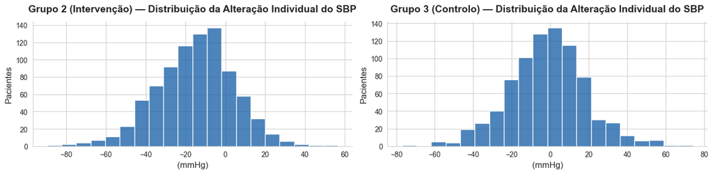

Para avaliar se o efeito do tratamento observado foi consistente entre os diferentes grupos demográficos, a diferença na alteração individual média entre os grupos de intervenção e de controlo foi calculada separadamente para cada combinação de género e grupo etário.

| Gender | Age_group | TotalN | MeanDiff |
| --- | --- | --- | --- |
| 0 | 30-40 | 22 | -16.841880 |
| 0 | 40-50 | 158 | -13.117028 |
| 0 | 50-60 | 342 | -14.669120 |
| 0 | 60-70 | 290 | -13.510155 |
| 0 | 70-80 | 109 | -6.234343 |
| 1 | 30-40 | 16 | -25.071429 |
| 1 | 40-50 | 102 | -12.184982 |
| 1 | 50-60 | 351 | -14.683250 |
| 1 | 60-70 | 206 | -12.800047 |
| 1 | 70-80 | 64 | -19.025616 |

A diferença estimada do efeito do tratamento foi negativa em todos os estratos de género e grupo etário, indicando uma maior redução da pressão arterial sistólica no grupo de intervenção em todos os subgrupos analisados. A magnitude da diferença estimada variou entre aproximadamente −6,23 e −25,07 mmHg. No entanto, as menores dimensões amostrais de alguns estratos significam que estas diferenças devem ser interpretadas com prudência e não devem ser consideradas como evidência de que o efeito do tratamento difere estatisticamente entre os grupos demográficos.

# Inferência Estatística

As estatísticas descritivas mostraram que o grupo de intervenção apresentou uma redução média de -15,205 mmHg, enquanto o grupo de controlo apresentou uma redução média de -1,456 mmHg. A diferença observada na alteração individual média foi, portanto, de −13,75 mmHg. Esta diferença descreve o que aconteceu na amostra do estudo. No entanto, o objetivo da inferência estatística é determinar o que pode ser razoavelmente concluído sobre a população subjacente da qual os participantes do estudo foram selecionados. Uma vez que diferentes amostras, ou diferentes atribuições aleatórias aos grupos, podem produzir resultados diferentes, é necessário avaliar se a diferença observada pode ser razoavelmente explicada por variação aleatória.

## Teste de Hipóteses com Teste Estatístico t de Welch

### Teste Estatístico t ao Nível Global

Na etapa seguinte, a diferença observada na alteração individual média de −13,75 mmHg foi testada face à hipótese nula. De acordo com a hipótese nula, assume-se que não existe diferença na alteração média da SBP entre o grupo de intervenção e o grupo de controlo. Os resultados do teste de hipóteses apresentados na tabela seguinte fornecem uma evidência forte contra a hipótese nula de ausência de diferença na alteração média da PAS entre os dois grupos (t = −14,15, p < 0,001). Por conseguinte, a diferença observada de −13,75 mmHg é estatisticamente significativa. O valor da estatística t de −14,15 indica quão distante a diferença observada está do valor definido pela hipótese nula, medida em erro padrão.

|  | Value |
| --- | --- |
| t-statistic | -1.414784e+01 |
| p-value | 5.630134e-43 |

### Teste Estatístico t por Género e Grupo Etário

Para avaliar se a evidência de uma diferença entre os grupos de intervenção e de controlo era consistente entre os subgrupos demográficos, foram realizados testes estatísticos t de Welch separados para cada combinação de género e grupo etário. Nove das dez comparações entre subgrupos produziram resultados estatisticamente significativos ao nível de significância de 5%. A única comparação não significativa foi observada nos participantes do Género 0 com idade entre 70 e 80 anos (p = 0,146).

| Gender | Age_group | t-statistic | p-value |
| --- | --- | --- | --- |
| 0 | 30-40 | -2.289131 | 0.033488 |
| 0 | 40-50 | -4.535933 | 0.000012 |
| 0 | 50-60 | -7.062581 | 0.000000 |
| 0 | 60-70 | -5.835202 | 0.000000 |
| 0 | 70-80 | -1.465776 | 0.145691 |
| 1 | 30-40 | -2.448802 | 0.028396 |
| 1 | 40-50 | -2.613294 | 0.011085 |
| 1 | 50-60 | -7.151044 | 0.000000 |
| 1 | 60-70 | -4.649111 | 0.000006 |
| 1 | 70-80 | -3.106248 | 0.003073 |

## Intervalo de Confiança

### Intervalo de Confiança Global

Enquanto o teste de hipóteses avalia se existe evidência de uma diferença entre os dois grupos, um intervalo de confiança fornece uma estimativa do intervalo plausível para a diferença na alteração individual média da pressão arterial sistólica. Foi calculado um intervalo de confiança de 95% para a diferença entre os grupos de intervenção e de controlo. O cálculo utiliza o método de Welch, que não assume que os dois grupos apresentam variâncias iguais. A diferença observada foi calculada como a alteração individual média no grupo de intervenção menos a alteração individual média no grupo de controlo. O intervalo de confiança resultante é apresentado abaixo.

|  | Confidence interval |
| --- | --- |
| Lower | -15.654547 |
| Upper | -11.842465 |

O intervalo de confiança de 95% varia entre −15,65 mmHg e −11,84 mmHg. Isto indica que estima-se que a diferença na alteração individual média se situe dentro deste intervalo, com o grupo de intervenção a apresentar uma maior redução da pressão arterial sistólica do que o grupo de controlo. Todo o intervalo de confiança se encontra abaixo de zero, o que é consistente com a rejeição da hipótese nula. Uma vez que a diferença é calculada subtraindo o controlo à intervenção, os valores negativos indicam uma maior redução da pressão arterial sistólica no grupo de intervenção.

### Intervalo de Confiança por Género e Grupo Etário

A análise seguinte por subgrupos mostra que a diferença estimada na alteração individual média da pressão arterial sistólica foi negativa em todas as combinações de género e grupo etário, indicando uma maior redução no grupo de intervenção. Nove das dez comparações entre subgrupos foram estatisticamente significativas ao nível de 5%, com intervalos de confiança que não incluem zero. O único resultado não significativo foi observado nos participantes do Género 0 com idade entre 70 e 80 anos, para os quais o intervalo de confiança incluía zero. Estas análises por subgrupos permitem avaliar se o efeito global do tratamento foi, de forma geral, consistente entre os diferentes grupos demográficos.

| Gender | Age_group | MeanDiff | TotalN | t-statistic | p-value | Lower Confidence Interval | Upper Confidence Interval |
| --- | --- | --- | --- | --- | --- | --- | --- |
| 0 | 30-40 | -16.841880 | 22 | -2.289131 | 0.033488 | -32.223353 | -1.460408 |
| 0 | 40-50 | -13.117028 | 158 | -4.535933 | 0.000012 | -18.831213 | -7.402844 |
| 0 | 50-60 | -14.669120 | 342 | -7.062581 | 0.000000 | -18.754825 | -10.583415 |
| 0 | 60-70 | -13.510155 | 290 | -5.835202 | 0.000000 | -18.067869 | -8.952442 |
| 0 | 70-80 | -6.234343 | 109 | -1.465776 | 0.145691 | -14.667570 | 2.198883 |
| 1 | 30-40 | -25.071429 | 16 | -2.448802 | 0.028396 | -47.069377 | -3.073480 |
| 1 | 40-50 | -12.184982 | 102 | -2.613294 | 0.011085 | -21.493521 | -2.876442 |
| 1 | 50-60 | -14.683250 | 351 | -7.151044 | 0.000000 | -18.722073 | -10.644426 |
| 1 | 60-70 | -12.800047 | 206 | -4.649111 | 0.000006 | -18.228627 | -7.371467 |
| 1 | 70-80 | -19.025616 | 64 | -3.106248 | 0.003073 | -31.317597 | -6.733635 |

## Pressupostos e Verificações de Diagnóstico

Antes de interpretar os resultados da análise estatística, foram considerados os pressupostos subjacentes ao teste estatístico t de Welch para duas amostras. Estes incluem a independência das observações, uma variável de resultado quantitativa e uma distribuição amostral aproximadamente normal da diferença entre as médias dos grupos. Os dados foram também analisados para identificar possíveis valores atípicos que pudessem influenciar desproporcionalmente os resultados.

Alguns pressupostos, como a independência, dependem sobretudo da elaboração do estudo e não podem ser estabelecidos apenas a partir dos dados observados. Outras características, como a distribuição e a presença de observações extremas, podem ser avaliadas utilizando os dados disponíveis.

### Variável de Resultado Quantitativa

A variável de resultado, SBP_Change, representa a alteração individual da pressão arterial sistólica ao longo do período de 12 meses e é medida em mmHg. Enquanto variável quantitativa contínua, é adequada para comparar a alteração individual média entre os grupos de intervenção e de controlo.

### Normalidade Aproximada

A distribuição de SBP_Change foi avaliada separadamente para cada grupo utilizando a assimetria e a curtose em excesso. Ambos os grupos apresentam baixa assimetria, com valores de −0,182 para o grupo de intervenção e 0,042 para o grupo de controlo. A curtose em excesso foi de 0,438 e 0,651, respetivamente, indicando apenas um desvio moderado em relação à curtose de uma distribuição normal. Tendo em conta estes resultados e as dimensões amostrais relativamente grandes de 847 e 813 participantes, não existe indicação de um desvio substancial da normalidade que possa comprometer a validade do teste estatístico t de Welch.

|  | Group 2 | Group 3 |
| --- | --- | --- |
| n | 847.000000 | 813.000000 |
| Mean | -15.204841 | -1.456335 |
| Standard deviation | 19.491746 | 20.076737 |
| Skewness | -0.182346 | 0.042285 |
| Excess kurtosis | 0.438428 | 0.651440 |

### Valores Atípicos

Os potenciais valores atípicos em SBP_Change foram identificados separadamente para cada grupo utilizando o critério de 1,5 × AIQ. Foram identificadas onze observações (1,30%) no grupo de intervenção, enquanto 17 observações (2,09%) foram identificadas no grupo de controlo. Embora estas observações representem alterações individuais invulgarmente elevadas, correspondem apenas a uma pequena proporção das observações de cada grupo. Os potenciais valores atípicos não foram removidos automaticamente, uma vez que um valor extremo não indica necessariamente que a observação esteja incorreta. A menos que existam evidências de que uma observação resulta de um erro de medição ou de introdução de dados, esta deve ser mantida na análise. Foi posteriormente realizada uma análise de sensibilidade para avaliar se estes potenciais valores atípicos afetam de forma relevante as conclusões estatísticas.

|  | Group 2 | Group 3 |
| --- | --- | --- |
| Q1 | -27.50 | -14.50 |
| Q3 | -2.50 | 11.00 |
| IQR | 25.00 | 25.50 |
| Lower bound | -65.00 | -52.75 |
| Upper bound | 35.00 | 49.25 |
| Number of potential outliers | 11 | 17 |
| Percentage of potential outliers | 1.30 | 2.09 |

Os seguintes diagramas de caixa mostram que o grupo de intervenção está centrado num valor consideravelmente inferior ao do grupo de controlo, em concordância com a diferença observada na tabela acima. Um pequeno número de observações ultrapassa os limites dos bigodes em ambos os grupos, indicando potenciais valores atípicos.

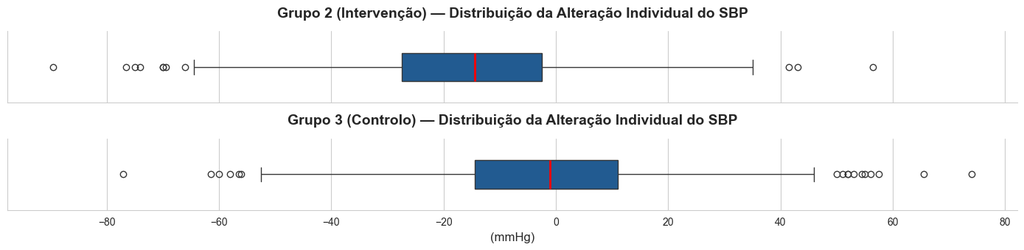

Uma verificação de sensibilidade excluindo os potenciais valores atípicos produziu um resultado muito semelhante (t = −14,37, p < 0,001), em comparação com o resultado original (t = −14,15, p < 0,001). Isto indica que a conclusão estatística não é significativamente influenciada pelos potenciais valores atípicos. Por conseguinte, as observações identificadas foram mantidas na análise principal.

|  | Value |
| --- | --- |
| t-statistic | -1.436580e+01 |
| p-value | 3.786487e-44 |

# Interpretação e Limitações

A análise fornece evidência forte de uma diferença na alteração individual média da pressão arterial sistólica entre os grupos de intervenção e de controlo. O grupo de intervenção apresentou uma redução substancialmente maior, com uma diferença observada de aproximadamente −13,75 mmHg, calculada como a média do grupo de controlo subtraída à média do grupo de intervenção.

O teste t de Welch produziu uma estatística t de aproximadamente −14,15 e um valor-p de aproximadamente 5,63 × 10⁻⁴³, fornecendo evidência muito forte contra a hipótese nula de ausência de diferença entre os grupos. Este resultado é consistente com o intervalo de confiança de 95% para a diferença, que varia entre aproximadamente −15,65 e −11,84 mmHg e não inclui zero.

O intervalo de confiança fornece uma estimativa do intervalo plausível para a diferença na alteração individual média. Com base nos dados da amostra e nos pressupostos da análise, estima-se que a diferença se situe entre aproximadamente −15,65 e −11,84 mmHg. Uma vez que a diferença foi calculada subtraindo o controlo à intervenção, os valores negativos indicam uma maior redução da pressão arterial sistólica no grupo de intervenção.

O estudo subjacente foi um ensaio clínico controlado e aleatorizado por agrupamentos, com a aleatorização realizada ao nível dos locais. Este desenho de estudo sustenta a interpretação das diferenças entre os grupos de intervenção e de controlo como evidência de um efeito da intervenção. A presente análise concentra-se na diferença na alteração individual média, utilizando um teste estatístico t de Welch para duas amostras, e não tem explicitamente em conta a estrutura de agrupamentos dos participantes dentro dos diferentes locais.

A análise depende também dos pressupostos subjacentes ao teste estatístico t de Welch. A avaliação de diagnóstico não identificou preocupações substanciais relativamente à natureza quantitativa da variável de resultado, à normalidade aproximada ou à presença de observações extremas. A verificação de sensibilidade indicou ainda que os potenciais valores atípicos não afetaram de forma relevante a conclusão estatística.

Por fim, a análise concentra-se na alteração individual média da pressão arterial sistólica ao longo do período de 12 meses. Esta medida fornece um resumo da diferença entre os dois grupos, mas não capta toda a variabilidade das respostas individuais.

# Conclusões

Este estudo investigou se os grupos de intervenção e de controlo diferem na sua alteração individual média da pressão arterial sistólica ao longo de um período de 12 meses.

O grupo de intervenção apresentou uma redução substancialmente maior da pressão arterial sistólica, com uma diferença observada de aproximadamente −13,75 mmHg em comparação com o grupo de controlo. O teste estatístico t de Welch resultou numa estatística t de aproximadamente −14,15 e num valor-p de aproximadamente 5,63 × 10⁻⁴³. Ao nível de significância de 5%, a hipótese nula de ausência de diferença é, portanto, rejeitada.

O intervalo de confiança de 95% correspondente variou entre aproximadamente −15,65 e −11,84 mmHg, indicando que a diferença na alteração individual média é consistentemente negativa em todo o intervalo estimado.

De forma geral, a análise estatística fornece uma evidência forte de uma diferença na alteração individual média da pressão arterial sistólica entre os grupos de intervenção e de controlo, tendo o grupo de intervenção apresentado uma maior redução.